# Hankowsky_HW11

2022-11-18

Hankowsky Homework Solutions

# Basic Problems

## 22.16

Murder–Suicides by Deliberate Plane Crash. Some sociologists suspect that highly publicized suicides may trigger additional suicides. In one investigation of this hypothesis, D. P. Phillips collected information about 17 airplane crashes that were known (because of notes left behind) to be murder–suicides. For each of these crashes, Phillips reported an index of the news coverage (circulation in nine newspapers devoting space to the crash multiplied by length of coverage) and the number of multiple-fatality plane crashes during the week following the publicized crash. The data are exhibited in Display 22.12. (Data from D. P. Phillips, “Airplane Accident Fatalities Increase Just After Newspaper Stories AboutMurder and Suicide,” Science 201 (1978): 748–50.) Is there evidence that the mean number of crashes increases with increasing levels of publicity of a murder–suicide?

```r
#read in the data
planes <- Sleuth3::ex2216

#take a look at the data
head(planes)
```

```
##   Index Crashes
## 1   376       8
## 2   347       5
## 3   322       8
## 4   104       4
## 5   103       6
## 6    98       4
```

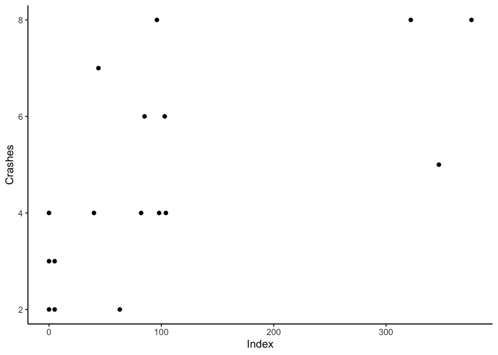

```r
#plot the data
planes %>%
  ggplot() +
  geom_point(aes(x = Index, y = Crashes)) +
  theme_classic()
```

```r
# REGRESSION ANALYSIS USING BACKWARD ELIMINATION
planes_glm <- glm(Crashes ~ Index, family = poisson, data = planes)
summary(planes_glm)
```

```
##
## Call:
## glm(formula = Crashes ~ Index, family = poisson, data = planes)
##
## Deviance Residuals:
##     Min       1Q   Median       3Q      Max
## -1.1974  -0.3978  -0.1766   0.3537   1.4919
##
## Coefficients:
##              Estimate Std. Error z value Pr(>|z|)
## (Intercept) 1.3098588  0.1582327   8.278   <2e-16 ***
## Index       0.0019933  0.0008166   2.441   0.0146 *
## ---
## Signif. codes:  0 '***' 0.001 '**' 0.01 '*' 0.05 '.' 0.1 ' ' 1
##
## (Dispersion parameter for poisson family taken to be 1)
##
##     Null deviance: 15.295  on 16  degrees of freedom
## Residual deviance:  9.794  on 15  degrees of freedom
## AIC: 70.365
##
## Number of Fisher Scoring iterations: 4
```

```r
#back transform the estimates
exp(cbind(OR = coef(planes_glm), confint(planes_glm)))
```

```
##                   OR    2.5 %   97.5 %
## (Intercept) 3.705650 2.681277 4.991363
## Index       1.001995 1.000340 1.003560
```

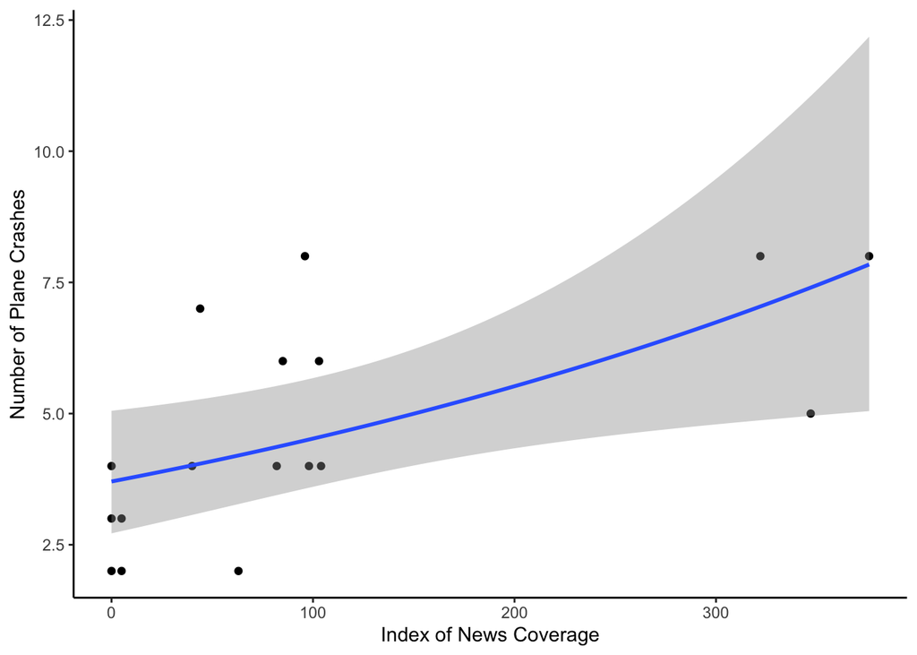

```r
#Presentation plot
planes %>%
  ggplot(aes(x = Index, y = Crashes)) +
  geom_point() +
  geom_smooth(method = 'glm', method.args = list(family = 'poisson')) +
  labs(x = "Index of News Coverage", y = "Number of Plane Crashes") +
  theme_classic()
```

## 22.20

Cancer Deaths of Atomic Bomb Survivors. The data in Display 22.13 are the number of cancer deaths among survivors of the atomic bombs dropped on Japan during World War II, categorized by time (years) after the bomb that death occurred and the amount of radiation exposure that the survivors received from the blast. (Data from D. A. Pierce, personal communication.) Also listed in each cell is the person-years at risk, in 100’s. This is the sumtotal of all years spent by all persons in the category. Suppose that the mean number of cancer deaths in each cell is Poisson with mean ! D risk”rate, where risk is the person-years at risk and rate is the rate of cancer deaths per person per year. It is desired to describe this rate in terms of the amount of radiation, adjusting for the effects of time after exposure. (a) Using log(risk) as an offset, fit the Poisson log-linear regression model with time after blast treated as a factor (with seven levels) and with rads and rads-squared treated as covariates. Look at the deviance statistic and the deviance residuals. Does extra-Poisson variation seem to be present? Is the rads-squared term necessary? (b) Try the same model as in part (a); but instead of treating time after bomb as a factor with seven levels, compute the midpoint of each interval and include log(time) as a numerical explanatory variable. Is the deviance statistic substantially larger in this model, or does it appear that time can adequately be represented through this single term? (c) Try fitting a model that includes the interaction of log(time) and exposure. Is the interaction significant? (d) Based on a good-fitting model, make a statement about the effect of radiation exposure on the number of cancer deaths per person per year (and include a confidence interval if you supply an estimate of a parameter).

```r
#read in the data
cancer <- Sleuth3::ex2220

#take a look at the data
head(cancer)
```

```
##   Exposure YearsAfter AtRisk Deaths
## 1        0       0to7    262     10
## 2        0      8to11    243     12
## 3        0     12to15    240     19
## 4        0     16to19    237     31
## 5        0     20to23    233     35
## 6        0     24to27    227     48
```

```r
#create the variables as dictated in the question
cancer <- cancer %>%
  mutate(exposuresquared = Exposure^2,
         time = case_when(
           YearsAfter == "0to7" ~ 3.5,
           YearsAfter == "8to11" ~ 9.5,
           YearsAfter == "12to15" ~ 13.5,
           YearsAfter == "16to19" ~ 17.5,
           YearsAfter == "20to23" ~ 21.5,
           YearsAfter == "24to27" ~ 25.5,
           YearsAfter == "28to31" ~ 29.5,
         ),
         log_time = log(time))


# PART A
cancer_glm_a <- glm(Deaths ~ YearsAfter + Exposure + exposuresquared + offset(log(AtRisk)), family = poisson, data = cancer)
summary(cancer_glm_a)
```

```
##
## Call:
## glm(formula = Deaths ~ YearsAfter + Exposure + exposuresquared +
##     offset(log(AtRisk)), family = poisson, data = cancer)
##
## Deviance Residuals:
##     Min       1Q   Median       3Q      Max
## -2.3598  -0.8416  -0.1011   0.4785   2.6816
##
## Coefficients:
##                    Estimate Std. Error z value Pr(>|z|)
## (Intercept)      -3.265e+00  1.890e-01 -17.276  < 2e-16 ***
## YearsAfter12to15  5.521e-01  2.371e-01   2.328  0.01990 *
## YearsAfter16to19  1.249e+00  2.132e-01   5.856 4.75e-09 ***
## YearsAfter20to23  1.404e+00  2.100e-01   6.687 2.28e-11 ***
## YearsAfter24to27  1.737e+00  2.038e-01   8.523  < 2e-16 ***
## YearsAfter28to31  2.032e+00  1.997e-01  10.174  < 2e-16 ***
## YearsAfter8to11   2.332e-01  2.528e-01   0.923  0.35614
## Exposure          4.446e-03  1.458e-03   3.050  0.00229 **
## exposuresquared  -7.438e-06  4.016e-06  -1.852  0.06404 .
## ---
## Signif. codes:  0 '***' 0.001 '**' 0.01 '*' 0.05 '.' 0.1 ' ' 1
##
## (Dispersion parameter for poisson family taken to be 1)
##
##     Null deviance: 335.75  on 41  degrees of freedom
## Residual deviance:  46.69  on 33  degrees of freedom
## AIC: 214.44
##
## Number of Fisher Scoring iterations: 5
```

```r
#deviance goodness-of-fit test
1-pchisq(cancer_glm_a$deviance, df = cancer_glm_a$df.residual)
```

```
## [1] 0.0575469
```

```r
# PART B
cancer_glm_b <- glm(Deaths ~ log_time + Exposure + exposuresquared + offset(log(AtRisk)), family = poisson, data = cancer)
summary(cancer_glm_b)
```

```
##
## Call:
## glm(formula = Deaths ~ log_time + Exposure + exposuresquared +
##     offset(log(AtRisk)), family = poisson, data = cancer)
##
## Deviance Residuals:
##     Min       1Q   Median       3Q      Max
## -2.7205  -0.8727  -0.3123   0.4238   3.4242
##
## Coefficients:
##                   Estimate Std. Error z value Pr(>|z|)
## (Intercept)     -5.515e+00  2.885e-01 -19.119  < 2e-16 ***
## log_time         1.223e+00  9.423e-02  12.982  < 2e-16 ***
## Exposure         4.438e-03  1.458e-03   3.044  0.00233 **
## exposuresquared -7.417e-06  4.017e-06  -1.847  0.06482 .
## ---
## Signif. codes:  0 '***' 0.001 '**' 0.01 '*' 0.05 '.' 0.1 ' ' 1
##
## (Dispersion parameter for poisson family taken to be 1)
##
##     Null deviance: 335.75  on 41  degrees of freedom
## Residual deviance:  73.68  on 38  degrees of freedom
## AIC: 231.43
##
## Number of Fisher Scoring iterations: 5
```

```r
# PART C
cancer_glm_c <- glm(Deaths ~ log_time + Exposure + exposuresquared + log_time:Exposure +  offset(log(AtRisk)), family = poisson, data = cancer)
summary(cancer_glm_c)
```

```
##
## Call:
## glm(formula = Deaths ~ log_time + Exposure + exposuresquared +
##     log_time:Exposure + offset(log(AtRisk)), family = poisson,
##     data = cancer)
##
## Deviance Residuals:
##     Min       1Q   Median       3Q      Max
## -2.7737  -0.8527  -0.1982   0.5410   3.2844
##
## Coefficients:
##                     Estimate Std. Error z value Pr(>|z|)
## (Intercept)       -5.338e+00  3.252e-01 -16.413   <2e-16 ***
## log_time           1.164e+00  1.070e-01  10.879   <2e-16 ***
## Exposure           4.742e-04  3.958e-03   0.120   0.9046
## exposuresquared   -7.577e-06  4.025e-06  -1.882   0.0598 .
## log_time:Exposure  1.324e-03  1.232e-03   1.075   0.2823
## ---
## Signif. codes:  0 '***' 0.001 '**' 0.01 '*' 0.05 '.' 0.1 ' ' 1
##
## (Dispersion parameter for poisson family taken to be 1)
##
##     Null deviance: 335.750  on 41  degrees of freedom
## Residual deviance:  72.426  on 37  degrees of freedom
## AIC: 232.18
##
## Number of Fisher Scoring iterations: 5
```

```r
# PART D
cancer_glm_d1 <- glm(Deaths ~ YearsAfter + Exposure + exposuresquared + offset(log(AtRisk)), family = poisson, data = cancer)
summary(cancer_glm_d1)
```

```
##
## Call:
## glm(formula = Deaths ~ YearsAfter + Exposure + exposuresquared +
##     offset(log(AtRisk)), family = poisson, data = cancer)
##
## Deviance Residuals:
##     Min       1Q   Median       3Q      Max
## -2.3598  -0.8416  -0.1011   0.4785   2.6816
##
## Coefficients:
##                    Estimate Std. Error z value Pr(>|z|)
## (Intercept)      -3.265e+00  1.890e-01 -17.276  < 2e-16 ***
## YearsAfter12to15  5.521e-01  2.371e-01   2.328  0.01990 *
## YearsAfter16to19  1.249e+00  2.132e-01   5.856 4.75e-09 ***
## YearsAfter20to23  1.404e+00  2.100e-01   6.687 2.28e-11 ***
## YearsAfter24to27  1.737e+00  2.038e-01   8.523  < 2e-16 ***
## YearsAfter28to31  2.032e+00  1.997e-01  10.174  < 2e-16 ***
## YearsAfter8to11   2.332e-01  2.528e-01   0.923  0.35614
## Exposure          4.446e-03  1.458e-03   3.050  0.00229 **
## exposuresquared  -7.438e-06  4.016e-06  -1.852  0.06404 .
## ---
## Signif. codes:  0 '***' 0.001 '**' 0.01 '*' 0.05 '.' 0.1 ' ' 1
##
## (Dispersion parameter for poisson family taken to be 1)
##
##     Null deviance: 335.75  on 41  degrees of freedom
## Residual deviance:  46.69  on 33  degrees of freedom
## AIC: 214.44
##
## Number of Fisher Scoring iterations: 5
```

```r
cancer_glm_d2 <- update(cancer_glm_d1, ~ . - exposuresquared)
summary(cancer_glm_d2)
```

```
##
## Call:
## glm(formula = Deaths ~ YearsAfter + Exposure + offset(log(AtRisk)),
##     family = poisson, data = cancer)
##
## Deviance Residuals:
##      Min        1Q    Median        3Q       Max
## -2.03884  -0.79110  -0.01406   0.54891   3.06044
##
## Coefficients:
##                    Estimate Std. Error z value Pr(>|z|)
## (Intercept)      -3.2145521  0.1868854 -17.201  < 2e-16 ***
## YearsAfter12to15  0.5516986  0.2371116   2.327    0.020 *
## YearsAfter16to19  1.2482438  0.2132413   5.854 4.81e-09 ***
## YearsAfter20to23  1.4038777  0.2099958   6.685 2.31e-11 ***
## YearsAfter24to27  1.7366566  0.2037769   8.522  < 2e-16 ***
## YearsAfter28to31  2.0311438  0.1997202  10.170  < 2e-16 ***
## YearsAfter8to11   0.2333271  0.2527737   0.923    0.356
## Exposure          0.0018316  0.0004392   4.170 3.04e-05 ***
## ---
## Signif. codes:  0 '***' 0.001 '**' 0.01 '*' 0.05 '.' 0.1 ' ' 1
##
## (Dispersion parameter for poisson family taken to be 1)
##
##     Null deviance: 335.750  on 41  degrees of freedom
## Residual deviance:  50.106  on 34  degrees of freedom
## AIC: 215.86
##
## Number of Fisher Scoring iterations: 5
```

```r
#run the optimal model
cancer_glm_optimal <- glm(Deaths ~ YearsAfter + Exposure + offset(log(AtRisk)), family = poisson, data = cancer)
summary(cancer_glm_optimal)
```

```
##
## Call:
## glm(formula = Deaths ~ YearsAfter + Exposure + offset(log(AtRisk)),
##     family = poisson, data = cancer)
##
## Deviance Residuals:
##      Min        1Q    Median        3Q       Max
## -2.03884  -0.79110  -0.01406   0.54891   3.06044
##
## Coefficients:
##                    Estimate Std. Error z value Pr(>|z|)
## (Intercept)      -3.2145521  0.1868854 -17.201  < 2e-16 ***
## YearsAfter12to15  0.5516986  0.2371116   2.327    0.020 *
## YearsAfter16to19  1.2482438  0.2132413   5.854 4.81e-09 ***
## YearsAfter20to23  1.4038777  0.2099958   6.685 2.31e-11 ***
## YearsAfter24to27  1.7366566  0.2037769   8.522  < 2e-16 ***
## YearsAfter28to31  2.0311438  0.1997202  10.170  < 2e-16 ***
## YearsAfter8to11   0.2333271  0.2527737   0.923    0.356
## Exposure          0.0018316  0.0004392   4.170 3.04e-05 ***
## ---
## Signif. codes:  0 '***' 0.001 '**' 0.01 '*' 0.05 '.' 0.1 ' ' 1
##
## (Dispersion parameter for poisson family taken to be 1)
##
##     Null deviance: 335.750  on 41  degrees of freedom
## Residual deviance:  50.106  on 34  degrees of freedom
## AIC: 215.86
##
## Number of Fisher Scoring iterations: 5
```

```r
#back transform the estimates
exp(cbind(OR = coef(cancer_glm_optimal), confint(cancer_glm_optimal)))
```

```
##                          OR     2.5 %      97.5 %
## (Intercept)      0.04017332 0.0272123  0.05676607
## YearsAfter12to15 1.73619957 1.0975107  2.79206154
## YearsAfter16to19 3.48421876 2.3250849  5.38147858
## YearsAfter20to23 4.07095523 2.7365041  6.25301713
## YearsAfter24to27 5.67832667 3.8704892  8.62970413
## YearsAfter28to31 7.62280030 5.2431017 11.50461886
## YearsAfter8to11  1.26279450 0.7699860  2.08460641
## Exposure         1.00183326 1.0009374  1.00266485
```

Part A: There does seem to be extra-Poisson variation present. The residual deviance is greater than the residual degrees of freedom. A deviance goodness-of-fit test shows inconclusive evidence for extra-Poisson variation (p-value = 0.057). The rads-squared [Exposure-Squared] term is not necessary (p-value = 0.064).

Part B: The deviance is larger in this model. The deviance in this model was 73.68 on 38 degrees of freedom versus 46.69 on 33 degrees of freedom.

Part C: The is no evidence for an effect of the interaction of log(time):Exposure (p-value = 0.28).

# Supplemental Problems

## 22.18

Galapagos Islands. Reanalyze the data in Exercise 12.20 with number of native species as the response, but using log-linear regression. (a) Fit the model with log area, log elevation, log of distance from nearest island, and log area of nearest island as explanatory variables; and then check for extra- Poisson variation. (b) Use backward elimination to eliminate insignificant explanatory variables. (c) Describe the effects of the remaining explanatory variables.

```r
#read in the data
islands <- Sleuth3::ex1220

#take a look at the data
head(islands)
```

```
##         Island Total Native  Area Elev DistNear DistSc AreaNear
## 1       Baltra    58     23 25.09  332      0.6    0.6     1.84
## 2    Bartolome    31     21  1.24  109      0.6   26.3   572.33
## 3     Caldwell     3      3  0.21  114      2.8   58.7     0.78
## 4     Champion    25      9  0.10   46      1.9   47.4     0.18
## 5      Coamano     2      1  1.05  130      1.9    1.9   903.82
## 6 Daphne Major    18     11  0.34  119      8.0    8.0     1.84
```

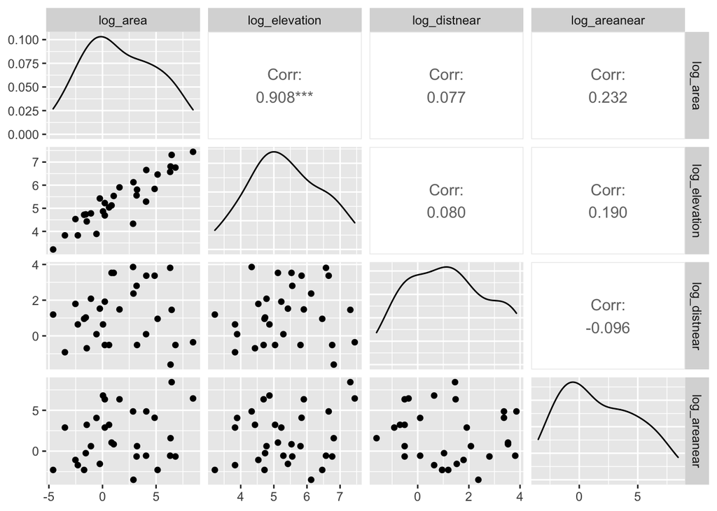

```r
#create the variables as dictated in the question
islands <- islands %>%
  mutate(log_area = log(Area),
         log_elevation = log(Elev),
         log_distnear = log(DistNear),
         log_areanear = log(AreaNear))

#scatterplot matrix of all the variables of interest
ggpairs(islands, columns = (9:12))
```

```r
# PART A
island_glm_a <- glm(Native ~ log_area + log_elevation + log_distnear + log_areanear, family = poisson, data = islands)
summary(island_glm_a)
```

```
##
## Call:
## glm(formula = Native ~ log_area + log_elevation + log_distnear +
##     log_areanear, family = poisson, data = islands)
##
## Deviance Residuals:
##     Min       1Q   Median       3Q      Max
## -3.4515  -1.6623   0.2330   0.7056   3.6582
##
## Coefficients:
##               Estimate Std. Error z value Pr(>|z|)
## (Intercept)    2.22136    0.45948   4.835 1.33e-06 ***
## log_area       0.24788    0.02965   8.360  < 2e-16 ***
## log_elevation  0.07663    0.09321   0.822  0.41101
## log_distnear  -0.06046    0.02111  -2.864  0.00418 **
## log_areanear  -0.05163    0.01083  -4.767 1.87e-06 ***
## ---
## Signif. codes:  0 '***' 0.001 '**' 0.01 '*' 0.05 '.' 0.1 ' ' 1
##
## (Dispersion parameter for poisson family taken to be 1)
##
##     Null deviance: 700.717  on 29  degrees of freedom
## Residual deviance:  95.764  on 25  degrees of freedom
## AIC: 243.05
##
## Number of Fisher Scoring iterations: 5
```

```r
# island_glm_a1 <- glm(Native ~ Area + Elev + DistNear + AreaNear, family = quasipoisson, data = islands)
# summary(island_glm_a1)

#deviance goodness-of-fit test
1-pchisq(island_glm_a$deviance, df = island_glm_a$df.residual)
```

```
## [1] 3.210638e-10
```

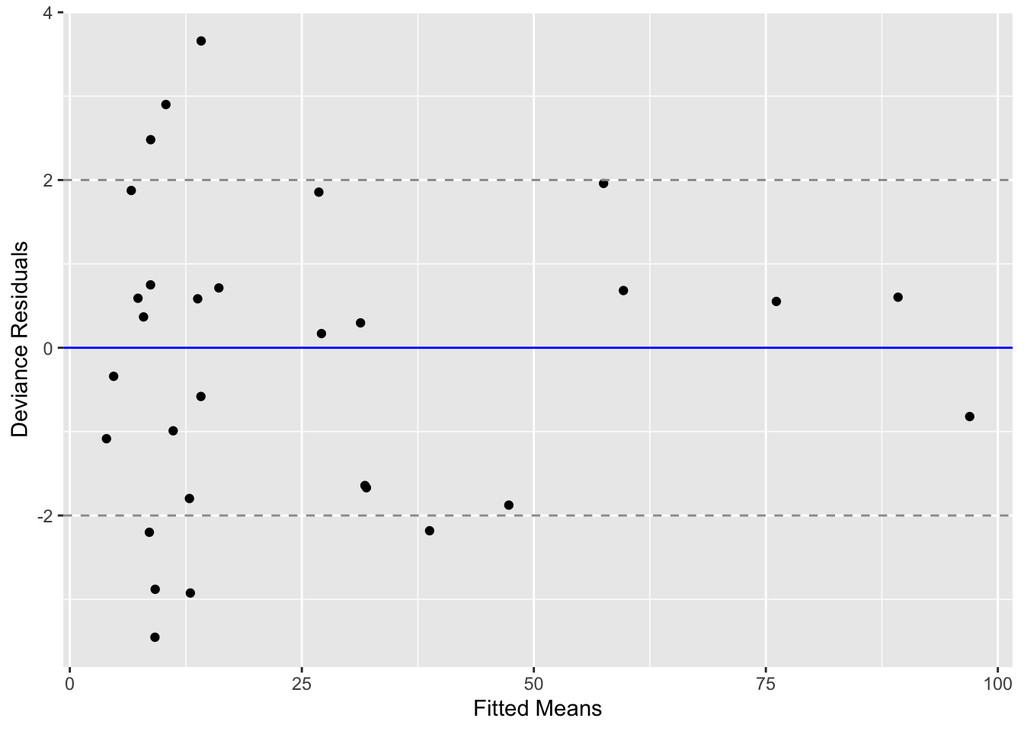

```r
#plot of deviance residuals against the fitted means
gf_point(residuals(island_glm_a, type = "deviance") ~ fitted(island_glm_a)) %>%
  gf_hline(yintercept = 0, color = "blue") %>%
  gf_hline(yintercept = 2, color = "gray60", linetype = 2) %>%
  gf_hline(yintercept = -2, color = "gray60", linetype = 2) %>%
  gf_labs(x = "Fitted Means", y = "Deviance Residuals")
```

```r
# PART B - using quasipoisson based on Part A
island_glm_b1 <- glm(Native ~ log_area + log_elevation + log_distnear + log_areanear, family = quasipoisson, data = islands)
summary(island_glm_b1)
```

```
##
## Call:
## glm(formula = Native ~ log_area + log_elevation + log_distnear +
##     log_areanear, family = quasipoisson, data = islands)
##
## Deviance Residuals:
##     Min       1Q   Median       3Q      Max
## -3.4515  -1.6623   0.2330   0.7056   3.6582
##
## Coefficients:
##               Estimate Std. Error t value Pr(>|t|)
## (Intercept)    2.22136    0.88621   2.507 0.019059 *
## log_area       0.24788    0.05718   4.335 0.000209 ***
## log_elevation  0.07663    0.17979   0.426 0.673576
## log_distnear  -0.06046    0.04071  -1.485 0.150036
## log_areanear  -0.05163    0.02089  -2.471 0.020623 *
## ---
## Signif. codes:  0 '***' 0.001 '**' 0.01 '*' 0.05 '.' 0.1 ' ' 1
##
## (Dispersion parameter for quasipoisson family taken to be 3.720004)
##
##     Null deviance: 700.717  on 29  degrees of freedom
## Residual deviance:  95.764  on 25  degrees of freedom
## AIC: NA
##
## Number of Fisher Scoring iterations: 5
```

```r
island_glm_b2 <- update(island_glm_b1, ~ . - log_elevation)
summary(island_glm_b2)
```

```
##
## Call:
## glm(formula = Native ~ log_area + log_distnear + log_areanear,
##     family = quasipoisson, data = islands)
##
## Deviance Residuals:
##     Min       1Q   Median       3Q      Max
## -3.4748  -1.6666   0.1745   0.6280   3.8165
##
## Coefficients:
##              Estimate Std. Error t value Pr(>|t|)
## (Intercept)   2.59389    0.13782  18.821  < 2e-16 ***
## log_area      0.27002    0.02388  11.306 1.55e-11 ***
## log_distnear -0.06099    0.04001  -1.524   0.1395
## log_areanear -0.05023    0.02041  -2.461   0.0208 *
## ---
## Signif. codes:  0 '***' 0.001 '**' 0.01 '*' 0.05 '.' 0.1 ' ' 1
##
## (Dispersion parameter for quasipoisson family taken to be 3.623204)
##
##     Null deviance: 700.717  on 29  degrees of freedom
## Residual deviance:  96.448  on 26  degrees of freedom
## AIC: NA
##
## Number of Fisher Scoring iterations: 5
```

```r
island_glm_b3 <- update(island_glm_b2, ~ . - log_distnear)
summary(island_glm_b3)
```

```
##
## Call:
## glm(formula = Native ~ log_area + log_areanear, family = quasipoisson,
##     data = islands)
##
## Deviance Residuals:
##     Min       1Q   Median       3Q      Max
## -3.3396  -1.7586  -0.3869   1.2155   3.7888
##
## Coefficients:
##              Estimate Std. Error t value Pr(>|t|)
## (Intercept)   2.49147    0.12851   19.39  < 2e-16 ***
## log_area      0.27860    0.02458   11.34 9.02e-12 ***
## log_areanear -0.04945    0.02104   -2.35   0.0263 *
## ---
## Signif. codes:  0 '***' 0.001 '**' 0.01 '*' 0.05 '.' 0.1 ' ' 1
##
## (Dispersion parameter for quasipoisson family taken to be 3.897306)
##
##     Null deviance: 700.72  on 29  degrees of freedom
## Residual deviance: 104.99  on 27  degrees of freedom
## AIC: NA
##
## Number of Fisher Scoring iterations: 5
```

```r
island_glm_optimal <- glm(Native ~ log_area + log_areanear, family = quasipoisson, data = islands)
summary(island_glm_optimal)
```

```
##
## Call:
## glm(formula = Native ~ log_area + log_areanear, family = quasipoisson,
##     data = islands)
##
## Deviance Residuals:
##     Min       1Q   Median       3Q      Max
## -3.3396  -1.7586  -0.3869   1.2155   3.7888
##
## Coefficients:
##              Estimate Std. Error t value Pr(>|t|)
## (Intercept)   2.49147    0.12851   19.39  < 2e-16 ***
## log_area      0.27860    0.02458   11.34 9.02e-12 ***
## log_areanear -0.04945    0.02104   -2.35   0.0263 *
## ---
## Signif. codes:  0 '***' 0.001 '**' 0.01 '*' 0.05 '.' 0.1 ' ' 1
##
## (Dispersion parameter for quasipoisson family taken to be 3.897306)
##
##     Null deviance: 700.72  on 29  degrees of freedom
## Residual deviance: 104.99  on 27  degrees of freedom
## AIC: NA
##
## Number of Fisher Scoring iterations: 5
```

```r
#back transform the estimates
exp(cbind(OR = coef(island_glm_optimal), confint(island_glm_optimal)))
```

```
##                      OR     2.5 %     97.5 %
## (Intercept)  12.0790092 9.2957554 15.3920250
## log_area      1.3212731 1.2602994  1.3879121
## log_areanear  0.9517502 0.9129506  0.9915493
```

```r
# island_glm_b1 <- glm(Native ~ Area + Elev + DistNear + AreaNear, family = quasipoisson, data = islands)
# summary(island_glm_b1)
#
# island_glm_b2 <- update(island_glm_b1, ~ . - DistNear)
# summary(island_glm_b2)
#
#
# #run the optimal model
# island_glm_optimal <- glm(Native ~ Area + Elev + AreaNear, family = quasipoisson, data = islands)
# summary(island_glm_optimal)
#
# #back transform the estimates
# exp(cbind(OR = coef(island_glm_optimal), confint(island_glm_optimal)))
```

## 22.24

Valve Failure in Nuclear Reactors. Display 22.16 shows characteristics and numbers of failures observed in valve types from one pressurized water reactor. There are five explanatory factors: system (1 D containment, 2 D nuclear, 3 D power conversion, 4 D safety, 5 D process auxiliary); operator type (1 D air, 2 D solenoid, 3 D motor-driven, 4 D manual); valve type (1 D ball, 2 D butterfly, 3 D diaphragm, 4 D gate, 5 D globe, 6 D directional control); head size (1 D less than 2 inches, 2 D 2–10 inches, 3 D 10–30 inches); and operation mode (1 D normally closed, 2 D normally open). The lengths of observation periods are quite different, as indicated in the last column, time. Using an offset for log of observation time, identify the factors associated with large numbers of valve failures. (Data from L. M. Moore and R. J. Beckman, “Appropriate One-Sided Tolerance Bounds on the Number of Failures Using Poisson Regression,” Technometrics 30 (1988): 283–90.)

```r
#read in the data
valves <- Sleuth3::ex2224

#take a look at the data
head(valves)
```

```
##   System Operator Valve Size Mode Failures Time
## 1      1        3     4    3    1        2    4
## 2      1        3     4    3    2        2    4
## 3      1        3     5    1    1        1    2
## 4      2        1     2    2    2        0    2
## 5      2        1     3    2    1        0    2
## 6      2        1     3    2    2        0    1
```

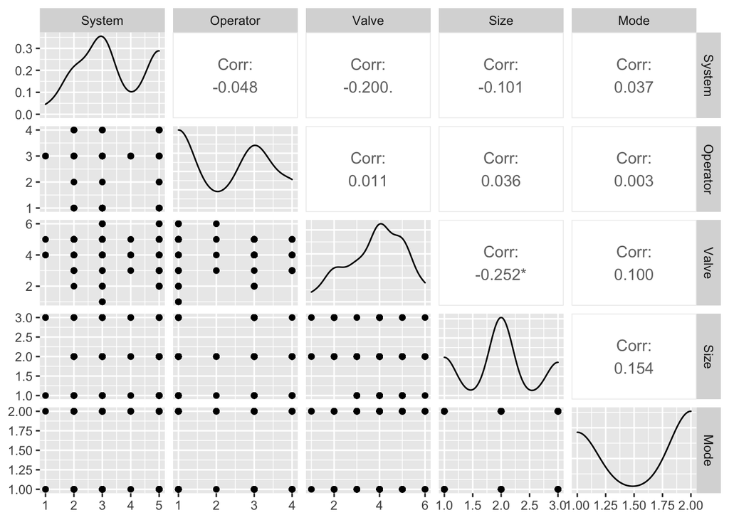

```r
#turn all the variable of interest into factors
valves1 <- valves %>%
  mutate(System = as.factor(System),
         Operator = as.factor(Operator),
         Valve = as.factor(Valve),
         Size = as.factor(Size),
         Mode = as.factor(Mode))

#scatterplot matrix of all the variables of interest
ggpairs(valves, columns = (1:5))
```

```r
# # REGRESSION ANALYSIS USING BACKWARD ELIMINATION - wrong analysis
# valves_glm1 <- glm(Failures ~ System + Operator + Valve + Size + Mode + offset(log(Time)), family = poisson, data = valves)
# summary(valves_glm1)
#
# valves_glm2 <- update(valves_glm1, ~ . - Mode)
# summary(valves_glm2)
#
# valves_glm3 <- update(valves_glm2, ~ . - System)
# summary(valves_glm3)
#
#
# #run the optimal model
# valves_glm_optimal <- glm(Failures ~  Operator + Valve + Size + offset(log(Time)), family = poisson, data = valves)
# summary(valves_glm_optimal)
#
# #back transform the estimates
# exp(cbind(OR = coef(valves_glm_optimal), confint(valves_glm_optimal)))



#Running the full model with the variables as factors
valves_glm1 <- glm(Failures ~ System + Operator + Valve + Size + Mode + offset(log(Time)), family = poisson, data = valves1)
summary(valves_glm1)
```

```
##
## Call:
## glm(formula = Failures ~ System + Operator + Valve + Size + Mode +
##     offset(log(Time)), family = poisson, data = valves1)
##
## Deviance Residuals:
##     Min       1Q   Median       3Q      Max
## -3.1892  -1.0074  -0.4357   0.3361   5.3138
##
## Coefficients:
##             Estimate Std. Error z value Pr(>|z|)
## (Intercept) -3.76867    0.81935  -4.600 4.23e-06 ***
## System2      0.91556    0.53184   1.721  0.08516 .
## System3      1.01881    0.50548   2.016  0.04385 *
## System4      1.22309    0.55518   2.203  0.02759 *
## System5      0.33292    0.58408   0.570  0.56869
## Operator2    0.70437    0.56669   1.243  0.21389
## Operator3   -1.19261    0.24851  -4.799 1.59e-06 ***
## Operator4   -2.47233    0.47660  -5.187 2.13e-07 ***
## Valve2       0.18533    0.76105   0.244  0.80761
## Valve3       0.60674    0.78107   0.777  0.43727
## Valve4       2.95894    0.60010   4.931 8.19e-07 ***
## Valve5       1.79318    0.61040   2.938  0.00331 **
## Valve6       1.00891    0.93009   1.085  0.27803
## Size2       -0.01219    0.28340  -0.043  0.96568
## Size3        1.61457    0.32104   5.029 4.93e-07 ***
## Mode2       -0.20934    0.19033  -1.100  0.27138
## ---
## Signif. codes:  0 '***' 0.001 '**' 0.01 '*' 0.05 '.' 0.1 ' ' 1
##
## (Dispersion parameter for poisson family taken to be 1)
##
##     Null deviance: 385.53  on 89  degrees of freedom
## Residual deviance: 195.68  on 74  degrees of freedom
## AIC: 332.02
##
## Number of Fisher Scoring iterations: 7
```